# Course Project 1

Edson Macedo

24 de junho de 2016

## Loading the Required Packages

```r
library('dplyr')
```

```r
library('ggplot2')
library('lubridate')
library('xtable')
```

## Loading and Preprocessing the Data

```r
activity <- read.csv('activity.csv')
```

## What is mean total number of steps taken per day?

1. Calculate the total number of steps taken per day

```r
StepsByDay <- summarize(group_by(activity, date), TotalSteps = sum(steps, na.rm = TRUE))
```

2. Make a histogram of the total number of steps taken each day

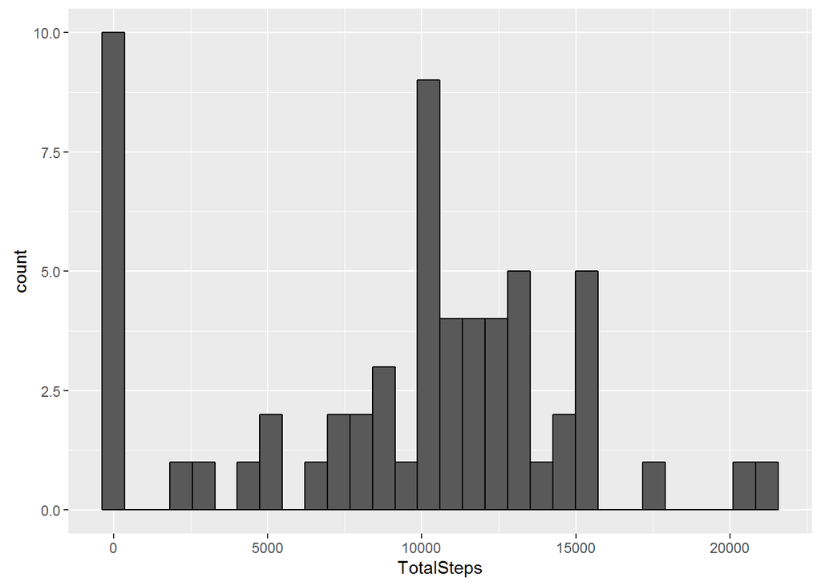

```r
qplot(data = StepsByDay, TotalSteps, geom = 'histogram', col = I('black'))
```

3. Calculate and report the mean and median of the total number of steps taken per day

```r
mean(StepsByDay$TotalSteps)
```

```
## [1] 9354.23
```

```r
median(StepsByDay$TotalSteps)
```

```
## [1] 10395
```

## What is the average daily activity pattern?

1.Make a time series plot (i.e. type = “l”) of the 5-minute interval (x-axis) and the average number of steps taken, averaged across all days (y-axis)

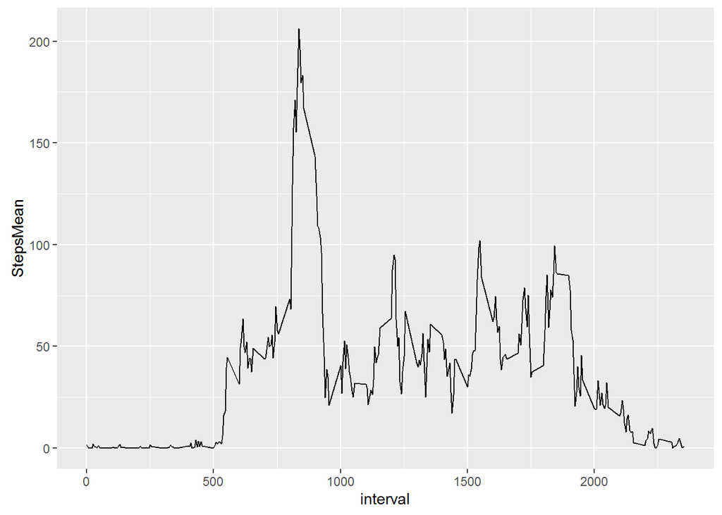

```r
StepsByInterval <- summarize(group_by(activity, interval), StepsMean = mean(steps, na.rm = TRUE))

qplot(data = StepsByInterval, x = interval, y = StepsMean, geom = 'line')
```

2. Which 5-minute interval, on average across all the days in the dataset, contains the maximum number of steps?

```r
arrange(.data = StepsByInterval, desc(StepsMean))[1,]
```

```
## Source: local data frame [1 x 2]
##
##   interval StepsMean
##      (int)     (dbl)
## 1      835  206.1698
```

## Imputing missing values

1. Calculate and report the total number of missing values in the dataset

```r
sum(is.na(activity$steps))
```

```
## [1] 2304
```

2. Devise a strategy for filling in all of the missing values in the dataset.
3. Create a new dataset that is equal to the original dataset but with the missing data filled in.

```r
activity_NoNa <- activity

for (row in c(1:17568)){
  if (is.na(activity_NoNa$steps[row]) == TRUE)
    activity_NoNa$steps[row] <- mean(filter(activity_NoNa, interval == activity_NoNa$interval[row])$steps, na.rm = TRUE)
}
```

4a. Make a histogram of the total number of steps taken each day.

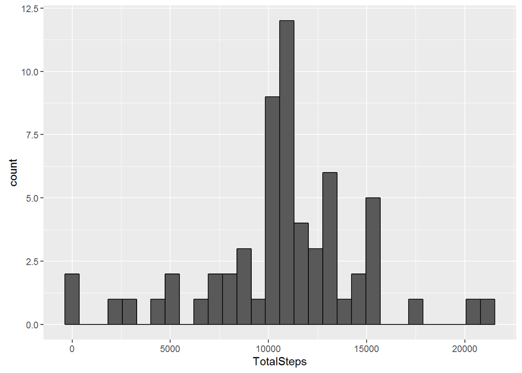

```r
StepsByDay_NoNa <- summarize(group_by(activity_NoNa, date), TotalSteps = sum(steps, na.rm = TRUE))

qplot(data = StepsByDay_NoNa, TotalSteps, geom = 'histogram', col = I('black'))
```

4b. Calculate and report the mean and median total number of steps taken per day.

```r
mean(StepsByDay_NoNa$TotalSteps)
```

```
## [1] 10766.19
```

```r
median(StepsByDay_NoNa$TotalSteps)
```

```
## [1] 10766.19
```

```r
Comparison <- data.frame(Mean = c(mean(StepsByDay$TotalSteps), mean(StepsByDay_NoNa$TotalSteps)),
                         Median = c(median(StepsByDay$TotalSteps), median(StepsByDay_NoNa$TotalSteps)),
                         row.names = c('With NAs', 'Without NAs'))

print(xtable(Comparison), type = 'html')
```

[output not shown]

[output not shown]

## Are there differences in activity patterns between weekdays and weekends?

1. Create a new factor variable in the dataset with two levels - “weekday” and “weekend” indicating whether a given date is a weekday or weekend day.

```r
activity_NoNa <- mutate(activity_NoNa, DayType = ifelse(wday(activity_NoNa$date) == 7 | wday(activity_NoNa$date) == 1,
                                                        'weekend', 'weekday'))

StepsByInterval_NoNa <- summarize(group_by(activity_NoNa, interval, DayType), StepsMean = mean(steps, na.rm = TRUE))
```

2. Make a panel plot containing a time series plot (i.e. type = “l”) of the 5-minute interval (x-axis) and the average number of steps taken, averaged across all weekday days or weekend days (y-axis).

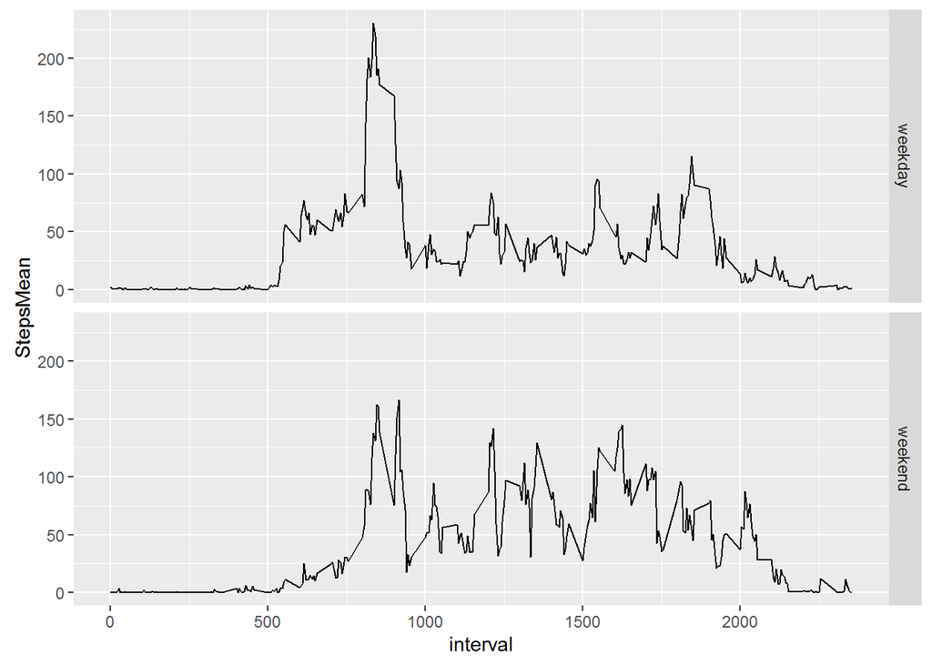

```r
qplot(data = StepsByInterval_NoNa, x = interval, y = StepsMean, geom = 'line', facets = DayType~.)
```